# Regression Models Content

Yadder Aceituno

March 19, 2018

# Week 1

## Libraries

```r
library(UsingR)
library(ggplot2)
library(manipulate)
```

## Load Data

```r
data(galton)
```

## Example 1

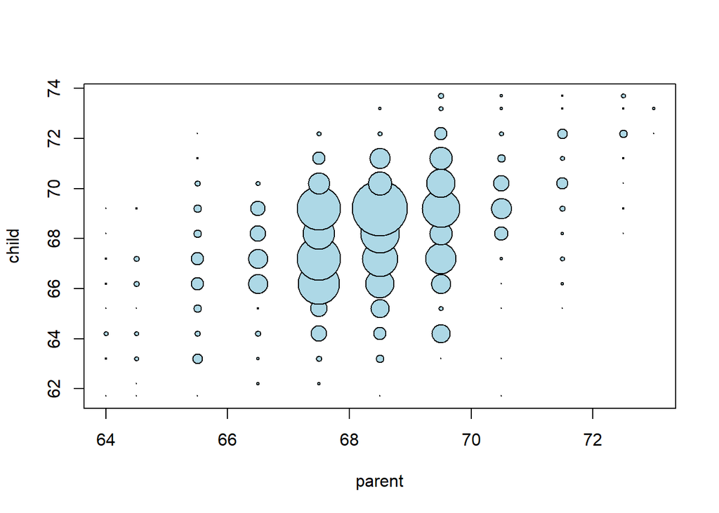

```r
## Without manipulate function
freqData <- as.data.frame(table(galton$child, galton$parent));
names(freqData) <- c("child", "parent", "freq");
plot(as.numeric(as.vector(freqData$parent)),
      as.numeric(as.vector(freqData$child)),
     pch = 21, col = "black", bg = "lightblue",
     cex = .15 * freqData$freq,
     xlab = "parent", ylab = "child");
```

```r
## With manipulate function
myPlot <- function(beta){
  y <- galton$child - mean(galton$child)
  x <- galton$parent - mean(galton$parent)
  freqData <- as.data.frame(table(x, y))
  names(freqData) <- c("child", "parent", "freq")
  plot(
    as.numeric(as.vector(freqData$parent)),
    as.numeric(as.vector(freqData$child)),
    pch = 21, col = "black", bg = "lightblue",
    cex = .15 * freqData$freq,
    xlab = "parent",
    ylab = "child")
  abline(0, beta, lwd = 3)
  points(0, 0, cex = 2, pch = 19)
  mse <- mean( (y - beta * x)^2 )
  title(paste("beta = ", beta, "mse = ", round(mse, 3)))
}

##Evaluation
##manipulate(myPlot(beta), beta = slider(0.6, 1.2, step = 0.02))
```

## Equations

### Variance

$$s^2 =\frac{1}{(n-1)}\sum_{i=1}^n(x_i - \bar{x})^2 = \frac{1}{(n-1)} ( \sum_{i=1}^n x_i^2 - n\bar{x} ^2)$$

### Standard Deviation

$$s = \sqrt {s^2}$$

### Normalizing Data

$$z_i = \frac{x_i - \bar{x}}{s}$$

### Covariance

It’s a measure of the joint variability of two random variables. If the greater values of one variable mainly correspond with the greater values of the other variable, and the same holds for the lesser values, i.e., the variables tend to show similar behavior, the covariance is positive. In the opposite case, when the greater values of one variable mainly correspond to the lesser values of the other, i.e., the variables tend to show opposite behavior, the covariance is negative.
$$Cov(x,y) = \frac {1}{(n-1)} \sum_{i=1}^n (x_i-\bar{x})(y_i-\bar{y}) = \frac {1}{(n-1)} (\sum_{i=1}^n x_iy_i - n\bar{x}\bar{y} )$$

### Correlation

A correlation coefficient is a numerical measure of some type of correlation, meaning a statistical relationship between two variables. The variables may be two columns of a given data set of observations, often called a sample, or two components of a multivariate random variable with a known distribution.
$$Cor(x,y) = \frac{Cov(x,y)}{s_x s_y} = Cor(y,x)$$
It’s imporant to take note about:
$$-1 \leqslant Cor(x,y) \leqslant 1$$
If
$$Cor(x,y) = 0 \implies \text{No linear relation}$$

Using least square we want to minimize the next sum
$$\sum_{i=1}^n[y_i - (\beta_0 + \beta_1x_i)]^2$$
We need to find beta0 and beta1 with this equations:
$$\beta_1 = Cor(y,x)\frac{s_y}{s_x}$$
$$\beta_0 = \bar{y} - \beta_1 \bar{x}$$

# Week 2

## Interpreting Coeficients

We have the probabilistic model for linear regression, including $\epsilon_i$ as our gaussian error.
$$Y_i = \beta_0 + \beta_1 X_i + \epsilon_i$$

Also, let’s consider the next one:
$$Y_i = \beta_0 + \beta_1X_i + \epsilon_i = \beta_0 + \frac{\beta_1}{a}(X_ia) + \epsilon_i = \beta_0 + \tilde{\beta_1}(X_ia) + \epsilon_i$$
Mutiplying $X$ by a factor $a$ results in dividing the coefficient by a factor of $a$.

## Example

### Diamond data set

Data is diamond prices (Singapore dollars) and diamond weight in carats (standard measure of diamond mass, 0.2 $g$)

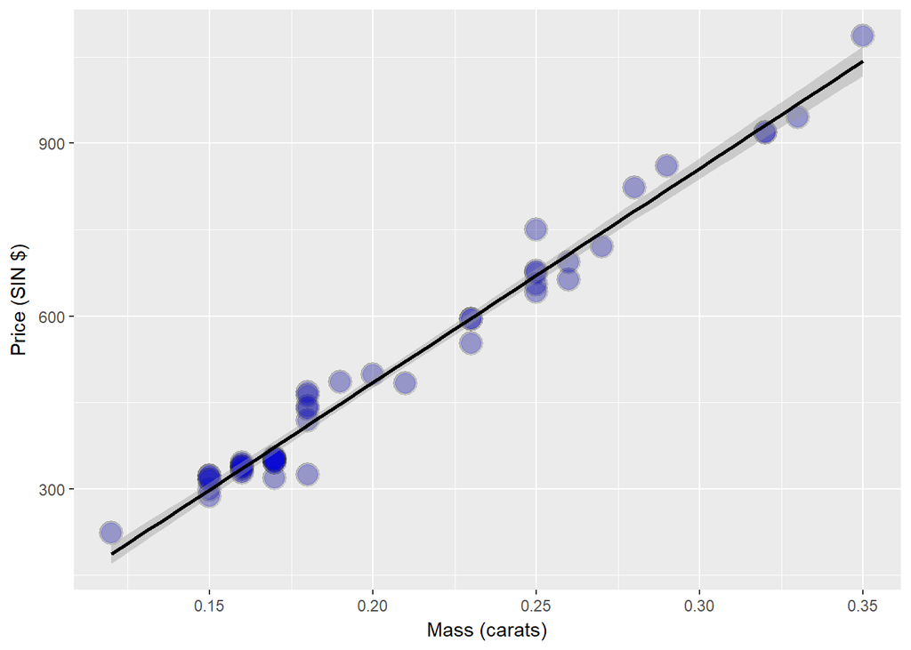

```r
library(UsingR);
library(ggplot2);

data(diamond);

g <- ggplot(diamond, aes(x = carat, y = price));
g <- g + xlab("Mass (carats)");
g <- g + ylab("Price (SIN $)");
g <- g + geom_point(size = 6, colour = "black", alpha = 0.2);
g <- g + geom_point(size = 5, colour = "blue", alpha = 0.2);
g <- g + geom_smooth(method = "lm", colour = "black");
g;
```

### Fitting the linear regression model

```r
fit <- lm(price ~ carat, data = diamond);
coef(fit);
```

```
## (Intercept)       carat
##   -259.6259   3721.0249
```

*Our slope $\beta_1 = 3721.0249$ says, we estimate an expected $3721.02$(SIN) dollar increase in price for every carat increase in mass of diamond.*

*The intercept $\beta_0 = -259.63$ is the expected price of a 0 carat diamond. (Not interesting)*

### Getting a more interpretable intercept

```r
fit2 <- lm(price ~ I(carat - mean(carat)), data = diamond);
coef(fit2);
```

```
##            (Intercept) I(carat - mean(carat))
##               500.0833              3721.0249
```

We see that the slope $\beta_1 = 3721.0249$ stay the same, but the Intercept $\beta_0 = 500.1$ is the expected price for the average sized diamond of the data.

```r
mean(diamond$carat);
```

```
## [1] 0.2041667
```

Now, suppose we need to change the units of carats by a factor of 10, so we know that we have to divide the $\beta_1$ by 10. Let’s check that:

```r
fit3 <- lm(price ~ I(carat * 10), data = diamond);
coef(fit3);
```

```
##   (Intercept) I(carat * 10)
##     -259.6259      372.1025
```

We see that out $\beta_1 = 372.1025$ is equal to $3721.0249 / 10$.

### Predicting the price of a diamond

Imagine we have this three new caret diamonds

```r
newd <- c(0.16, 0.27, 0.34);
```

And we have 2 ways to predict the values:

```r
## Using the formula beta_0 + beta_1 * carat
coef(fit)[1] + coef(fit)[2] * newd;
```

```
## [1]  335.7381  745.0508 1005.5225
```

```r
## Using predict function
predict(fit, newdata = data.frame(carat = newd));
```

```
##         1         2         3
##  335.7381  745.0508 1005.5225
```

## Residuals

Our observed outcome $i$ is $Y_i$ at a predictor value $X_i$

The predicted outcome $i$ is $\hat{Y_i}$ at a predictor value $X_i$

The model:
$$\hat{Y_i}=\hat{\beta_0} + \hat{\beta_1}X_i$$

We can define the residuals with
$$e_i = Y_i-\hat{Y_i}$$

Least Squares minimizes: $\sum_{i=1}^ne_i^2$

### Example

```r
data(diamond);
y <- diamond$price;
x <- diamond$carat;
n <- length(y);
fit <- lm(y~x);

## Getting the residuals (easy way)
e<- resid(fit);

yhat <- predict(fit);

## Lets see the residuals
e;
```

```
##           1           2           3           4           5           6
## -17.9483176  -7.7380691 -22.9483176 -85.1585661 -28.6303057   6.2619309
##           7           8           9          10          11          12
##  23.4721795  37.6311854 -38.7893116  24.4721795  51.8414339  40.7389488
##          13          14          15          16          17          18
##   0.2619309  13.4209369  -1.2098087  40.5287002  36.1029250 -44.8405542
##          19          20          21          22          23          24
##  79.3696943 -25.0508027  57.8414339   9.2619309 -20.9483176  -3.7380691
##          25          26          27          28          29          30
## -19.9483176  27.8414339 -54.9483176   8.8414339 -26.9483176  16.4721795
##          31          32          33          34          35          36
## -22.9483176 -13.1020453 -12.1020453  -0.5278205   3.2619309   2.2619309
##          37          38          39          40          41          42
##  -1.2098087 -43.2098087 -27.9483176 -23.3122938 -15.6303057  43.2672091
##          43          44          45          46          47          48
##  32.8414339   7.3696943   4.3696943 -11.5278205 -14.8405542  17.4721795
```

```r
## Lets see the predictions
yhat;
```

```
##         1         2         3         4         5         6         7
##  372.9483  335.7381  372.9483  410.1586  670.6303  335.7381  298.5278
##         8         9        10        11        12        13        14
##  447.3688  521.7893  298.5278  410.1586  782.2611  335.7381  484.5791
##        15        16        17        18        19        20        21
##  596.2098  819.4713  186.8971  707.8406  670.6303  745.0508  410.1586
##        22        23        24        25        26        27        28
##  335.7381  372.9483  335.7381  372.9483  410.1586  372.9483  410.1586
##        29        30        31        32        33        34        35
##  372.9483  298.5278  372.9483  931.1020  931.1020  298.5278  335.7381
##        36        37        38        39        40        41        42
##  335.7381  596.2098  596.2098  372.9483  968.3123  670.6303 1042.7328
##        43        44        45        46        47        48
##  410.1586  670.6303  670.6303  298.5278  707.8406  298.5278
```

Now lets plot the residuals

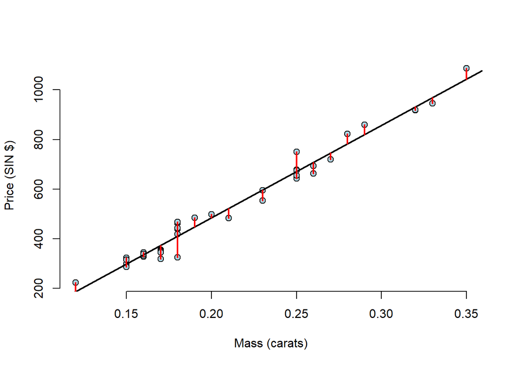

```r
plot(diamond$carat, diamond$price,
     xlab = "Mass (carats)",
     ylab = "Price (SIN $)",
     bg = "lightblue",
     col = "black", cex = 1.1, pch = 21, frame = FALSE);
abline(fit, lwd = 2);
for(i in 1: n)
  lines(c(x[i],x[i]), c(y[i], yhat[i]), col = "red", lwd = 2);
```

Lets do another plot for residuals

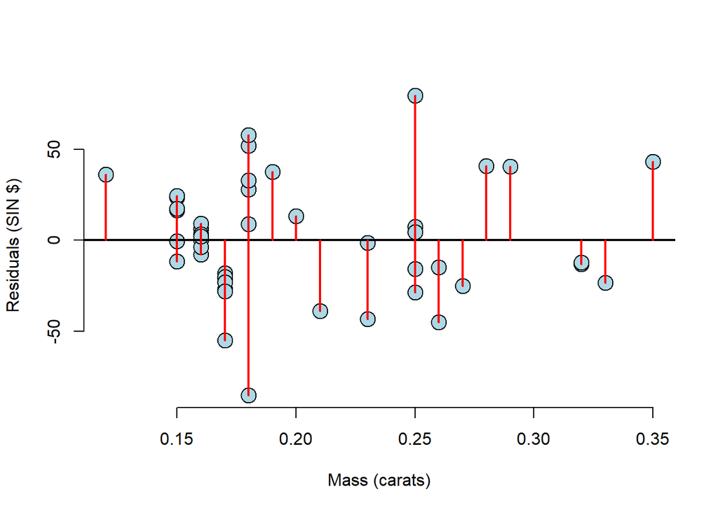

```r
plot(x,e,
     xlab="Mass (carats)",
     ylab="Residuals (SIN $)",
     bg = "lightblue",
     col = "black", cex = 2, pch = 21, frame = FALSE);
abline(h = 0, lwd = 2);
for(i in 1: n)
  lines(c(x[i], x[i]), c(e[i],0), col="red", lwd = 2);
```

### Estimating Residual Variance

We can estimate $\sigma^2$ is equal to $\frac{1}{n}\sum_{i=1}^ne_i^2$ the averaged sqared residual

Most people use:
$$\hat{\sigma}^2 = \frac{1}{n-2}\sum_{i=1}^ne_i^2$$

The $n - 2$ instead of $n$ is so that $E[\hat{\sigma}^2] = \sigma^2$

```r
y <- diamond$price;
x <- diamond$carat;
n <- length(y);
fit <- lm(y~x);

## Checking the residual variation
summary(fit)$sigma;
```

```
## [1] 31.84052
```

```r
## Calculating the residual variation
sqrt(sum(resid(fit)^2)/(n-2));
```

```
## [1] 31.84052
```

### Diamond data residual plot

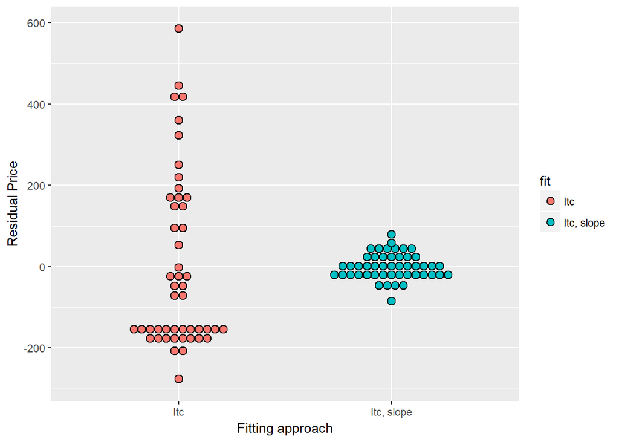

```r
e <- c(resid(lm(price~1, data = diamond)),
       resid(lm(price~carat, data = diamond)));
fit <- factor(c(rep("Itc", nrow(diamond)),
                rep("Itc, slope", nrow(diamond))));
g <- ggplot(data.frame(e = e, fit = fit), aes(y = e, x = fit, fill = fit));
g <- g + geom_dotplot(binaxis = "y", stackdir = "center", binwidth = 20);
g <- g + xlab("Fitting approach");
g <- g + ylab("Residual Price");
g;
```

### Total Variability

The total variability in our response is the variability around an intercept $\sum_{i=1}^n(Y_i - \bar{Y})^2$ The regression variability is the variability that is explained by adding the predictor $\sum_{i=1}^n(\hat{Y_i}-\bar{Y})^2$ The error variability is what’s leftover around the regression line $\sum_{i=1}^n(Y_i-\hat{Y_i})^2$

We have a neat fact:
$$\sum_{i=1}^n(Y_i - \bar{Y})^2 = \sum_{i=1}^n(Y_i - \hat{Y_i})^2 + \sum_{i=1}^n(\hat{Y_i}-\bar{Y_i})^2$$

R squared is the pecentage of the total variability that is explained by the linear relationship with the predictor:

$$R^2 = \frac{\sum_{i=1}^n(\hat{Y_i}-\bar{Y})^2}{\sum_{i=1}^n(Y_i - \bar{Y})^2}$$

### Heteroskedasticity

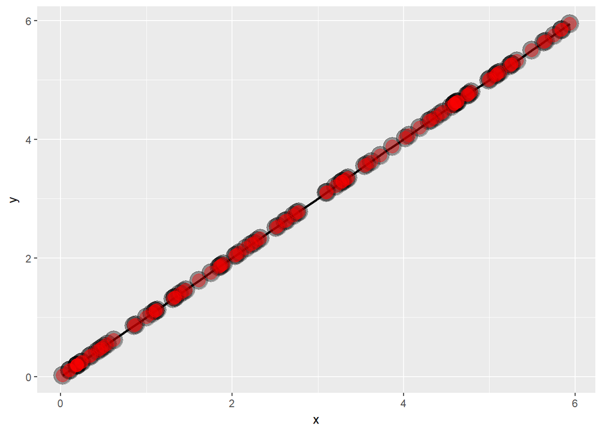

```r
x <- runif(100, 0, 6);
y <- x + rnorm(100, mean = 0, sd = 0.001 * x);
g <- ggplot(data.frame(x = x, y = y), aes(x = x, y = y));
g <- g + geom_smooth(method = "lm", colour = "black");
g <- g + geom_point(size = 7, colour= "black", alpha = 0.4);
g <- g + geom_point(size = 5, colour = "red", alpha = 0.4);
g;
```

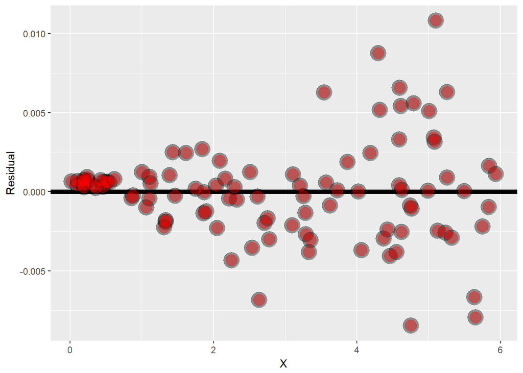

```r
## Getting rid of the blank space can be helpful
g <- ggplot(data.frame(x = x, y = resid(lm(y~x))), aes(x=x, y=y));
g <- g + geom_hline(yintercept = 0, size = 2);
g <- g + geom_point(size = 7, colour = "black", alpha = 0.4);
g <- g + geom_point(size = 5, colour = "red", alpha = 0.4);
g <- g + xlab("X") + ylab("Residual");
g;
```

## Inference in regression

### Review

Lets consider the model:
$$Y_i = \beta_0 + \beta_1X_i +\epsilon_i$$
$$\hat{\beta_0} = \bar{Y} - \hat{\beta_1}\bar{X}$$
$$\hat{\beta_1} = Cor(Y,X)\frac{Sd(Y)}{Sd(X)}$$

Review from statistical inference, can be used to test: $H_0: \theta = \theta_0$ versus $H_a: \theta >, <, \neq \theta_0$

Can be used to create a confidence interval for $\theta$ via $\hat{\theta} \pm Q_{1-\alpha/2}\hat{\sigma_{\hat{\theta}}}$ where $Q_{1-\alpha/2}$ is the relevant quantile from either a normal or T distribution.

### Results

Variance for the slope:
$$\sigma_{\hat{\beta_1}}^2 = Var(\hat{\beta_1}) = \sigma^2 / \sum_{i=1}^n(X_i-\bar{X})^2$$
The standard error for $\beta_1$:
$$\sigma_{\hat{\beta_1}} = \sqrt{\sigma^2 / \sum_{i=1}^n(X_i-\bar{X})^2}$$

Variance for the intercept:
$$\sigma_{\hat{\beta_0}}^2 = Var(\hat{\beta_0}) = \bigg( \frac{1}{n} + \frac{\bar{X}^2}{\sum_{i=1}^n(X_i-\bar{X})^2} \bigg) \sigma^2$$

The standard error for $\beta_0$:
$$\sigma_{\hat{\beta_0}} = \sqrt{\bigg( \frac{1}{n} + \frac{\bar{X}^2}{\sum_{i=1}^n(X_i-\bar{X})^2} \bigg) \sigma^2}$$

### Example

```r
library(UsingR);
data(diamond);
y <- diamond$price;
x <- diamond$carat;
n <- length(y);
beta1 <- cor(y,x) * sd(y) / sd(x);
beta0 <- mean(y) - beta1 * mean(x);
e <- y - beta0 - beta1 * x;
sigma <- sqrt(sum(e^2)/(n-2));
ssx <- sum((x - mean(x))^2);
seBeta0 <- ((1/n)+ mean(x)^2/ssx) ^ .5 * sigma;
seBeta1 <- sigma / sqrt(ssx);

## I assume that miu_beta0 and miu_beta1 is equal to 0
tBeta0 <- beta0 / seBeta0;
tBeta1 <- beta1 / seBeta1;

pBeta0 <- 2 * pt(abs(tBeta0), df = n - 2, lower.tail = FALSE);
pBeta1 <- 2 * pt(abs(tBeta1), df = n - 2, lower.tail = FALSE);

coefTable <- rbind(
  c(beta0, seBeta0, tBeta0, pBeta0),
  c(beta1, seBeta1, tBeta1, pBeta1));

colnames(coefTable) <- c("Estimate", "Std. Error", "t value", "P(>|t|)");
rownames(coefTable) <- c("(Intercept)", "x");


## Using lm function
fit <- lm(y ~ x);

## Comparing coefficients table
coefTable
```

```
##              Estimate Std. Error   t value      P(>|t|)
## (Intercept) -259.6259   17.31886 -14.99094 2.523271e-19
## x           3721.0249   81.78588  45.49715 6.751260e-40
```

```r
summary(fit)$coefficients;
```

```
##              Estimate Std. Error   t value     Pr(>|t|)
## (Intercept) -259.6259   17.31886 -14.99094 2.523271e-19
## x           3721.0249   81.78588  45.49715 6.751260e-40
```

### Getting Confidence Interval

```r
coeffs <- summary(fit)$coefficients;
intervalBeta0 <- coeffs[1,1] + c(1,-1) * qt(0.975, df = fit$df) * coeffs[1,2];
intervalBeta1 <- coeffs[2,1] + c(1,-1) * qt(0.975, df = fit$df) * coeffs[2,2];

intervalBeta0;
```

```
## [1] -224.7649 -294.4870
```

```r
intervalBeta1;
```

```
## [1] 3885.651 3556.398
```

### Prediction of outcomes

The obvious estimate for prediction at point $x_0$ is $\hat{\beta_0} + \hat{\beta_1}x_0$, but a standard error is needed to create a prediction interval.

$x_0$ SE, $\hat{\sigma}\sqrt{\frac{1}{n} + \frac{(x_0 - \bar{X})^2}{\sum_{i=1}^n(X_i-\bar{X})^2}}$

Prediction interval SE at $x_0$, $\hat{\sigma}\sqrt{1 + \frac{1}{n} + \frac{(x_0 - \bar{X})^2}{\sum_{i=1}^n(X_i-\bar{X})^2}}$

### Example

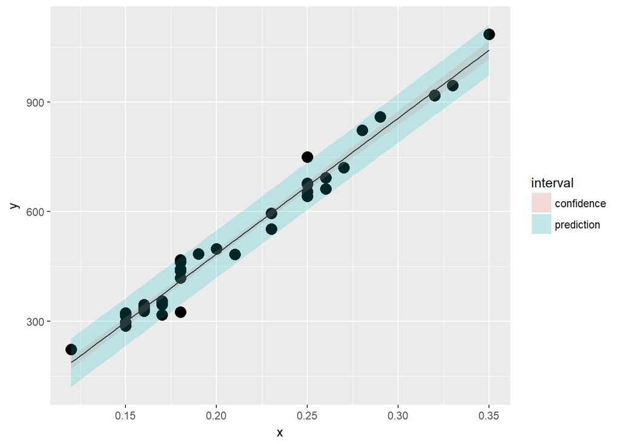

```r
library(ggplot2);
newx <- data.frame(x = seq(min(x), max(x), length = 100));
p1 <- data.frame(predict(fit, newdata = newx, interval = ("confidence")));
p2 <- data.frame(predict(fit, newdata = newx, interval = ("prediction")));
p1$interval <- "confidence";
p2$interval <- "prediction";
p1$x <- newx$x;
p2$x <- newx$x;
dat <- rbind(p1, p2);
names(dat)[1] <- "y";

g <- ggplot(dat, aes(x = x, y = y));
g <- g + geom_line();
g <- g + geom_point(data = data.frame(x = x, y = y), aes(x =x, y = y), size = 4);
g <- g + geom_ribbon(aes(ymin = lwr, ymax = upr, fill = interval), alpha = 0.2);
g;
```